# Lab 9: Correlation and Introduction to Simple Linear Regression

Author

Student

## Before you start:

1. Complete the Lab Primer linked in Canvas.
2. Be sure you have opened the `lab9-intro-two-quant-student.Rproj` file.
3. Change the name of the **QMD** file only to your last name, first initial, e.g., `OtterM-lab9-intro-two-quant-student.qmd`. You will have to close the QMD document to rename the file.
4. Change the “NAME” above after `author:` to your name, leaving it in quotes: “Monte Otter”

## Skills

- Given a study, distinguish between explanatory and response variables
- Given a set of raw data, make a scatterplot or regression output using R
- Given a set of raw data, be able to calculate correlation
- Be able to use correlation to identify the strength and direction of a linear association
- Given a scatterplot, identify patterns such as positive and negative associations
- Given standard regression output, identify and utilize key parts of the output (estimated slope, intercept)

These skills incorporate LTs 17 and R LTs R8, R9, and R10.

*Tip: putting two spaces after a line forces the next line in your Quarto document to also be a new line in your knitted document.*

*Tip: equations in will ignore any attempt to include spaces, unless you insert a `~` inside the equation where you want the space.* For example, in our BAC-Beers problem from class (hover your mouse over each formula to see what it would knit like): $x_{number of beers}$ versus $x_{number~of~beers}$

*Tip: If you want to test out two lines of code, such as for a plot (such as you’ve seen previously with piped functions), you have to run them **together**, not one at a time.*

Here are some symbols that you might find useful:

$\hat{y}$

$\hat{y}_{word}$

$x_{word}$

$\beta_{word}$

**Reminder:** Before you start the lab, add the code that will load any other packages you might need into this code chunk.

## Scenario 1: Brain Weight in Healthy Adults

**Feedback given on the following questions:** 1.2, 1.5, 1.9, 1.10, 1.13 You are welcome to bring questions checked for completeness to office hours for individual feedback.

A study published in 1905 had the goal of predicting the approximate weight of the human brain in healthy adults and theorized that the size of the head would be a good predictor. The researchers at Middlesex teaching Hospital decided to focus on post-mortem patients who had suffered accidental deaths, as a reasonable way to collect the data for the population of healthy adults. Over the period of three years, they randomly selected post-mortem patients and for each case, measured first the head size (cm<sup>3</sup>) and then took out the brain and weighed it (in grams). The researchers defined the size of the head as the product of the three principal diameters of the head. Additionally, the patients’ sex (male or female) and age group (20-46 or 46+) was recorded. The data is in `brain-head.csv`.  
*Source: R.J. Gladstone (1905). “A Study of the Relations of the Brain to to the Size of the Head”, Biometrika, Vol. 4, pp105-123*

### 1.1.

Name the response and explanatory variables of interest and, for each, state the type of variable (quantitative or qualitative).

> Response: brain weight in grams (quantitative, continuous)

> Explanatory: head size in cm^3 (quantiative, continuous)

### 1.2.

**Small Errors:**  
Be sure to write answers with full context.

What type of study is this (observational or experimental)? Justify your answer in the context of the study.

> This is an observational study since there was no random assignment of variables. Head sizes were not randomly assigned to cases.

### 1.3.

Exploratory Data Analysis: Insert a code chunk below to create an appropriate graphic and calculate any appropriate summary statistics. Modify the plot so that the y axis spans from 900 to 1800 grams.

```r
brain <- read_csv("brain-head.csv", show_col_types = FALSE) #reads in the csv file
names(brain)
```

```
[1] "Sex"         "AgeRange"    "HeadSize"    "BrainWeight"
```

```r
cor(BrainWeight ~ HeadSize, data = brain)
```

```
[1] 0.7995697
```

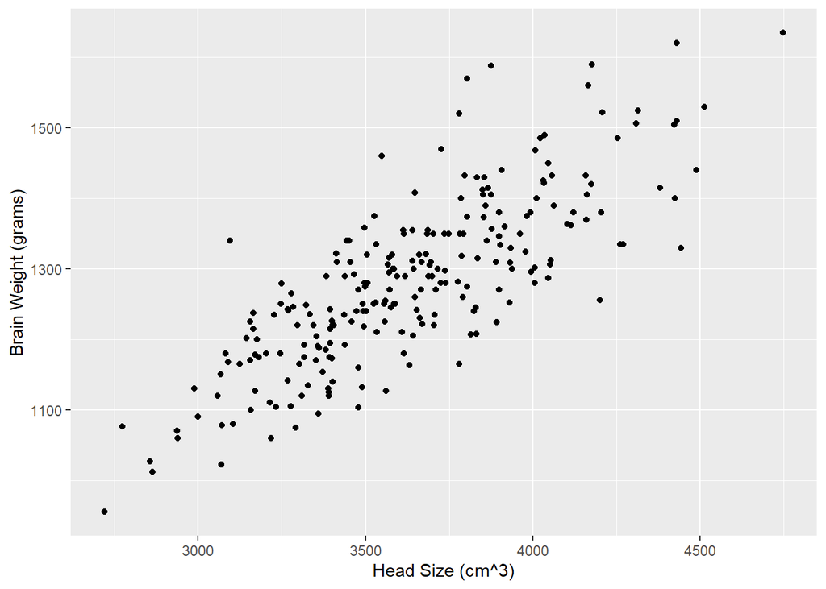

```r
gf_point(BrainWeight ~ HeadSize, data = brain,
              ylab="Brain Weight (grams)",
              xlab="Head Size (cm^3)")
```

```r
ylim(900,1800)
```

```
<ScaleContinuousPosition>
 Range:
 Limits:  900 -- 1.8e+03
```

**Feedback for all students:**  
Refer to page 8-3 for the arguments to supply to gf_point() and how to used gf_lims() to include an axis modification. Refer to page 8-7 for the code to calculate correlation.

### 1.4.

What is the simplest form (linear, nonlinear, etc) of the relationship between the brain weight and head size of healthy adults?

> There is a linear relationship between brain wieght and head size of healthy adults.

### 1.5.

**Conceptual Errors:**  
You should always cite the evidence you used (r)! Remember to identify the relationship as linear

**Small Errors:**  
According to the scale for this class, this correlation would be strong (refer to page 8-5).

What is the strength and direction of the linear relationship? Cite your evidence. (You may want to refer to 1.3 / use your best evidence.)

> based on the scatterplot in 1.3, we can see a moderately strong, positive relationship between brain wieght and head size of healthy adults. This is shown by the upward slope.

### 1.6.

Create a scatterplot of the data, including both the axis modification and the estimated linear model on the plot.

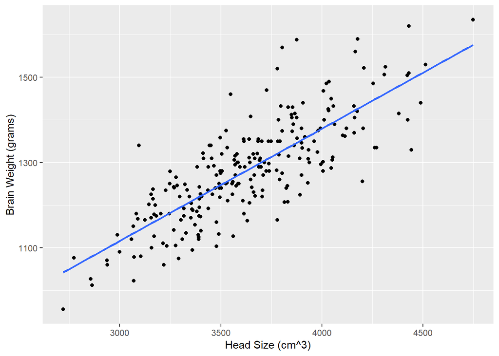

```r
 gf_point(BrainWeight ~ HeadSize, data = brain,
              ylab="Brain Weight (grams)",
              xlab="Head Size (cm^3)") |>
  gf_lm()
```

**Feedback for all students:**  
Remember to plot your scatterplot using response ~ explanatory in that order, and to include both the full specific variables measured (brain weight (g) and head size (cm3) and the full population (healthy adults) in the axis labels

### 1.7.

Create your linear model. Then, write the code below to print out the coefficients for your estimates of slope and intercept of your linear model between between the brain weight and head size and write them below.

```r
# Create the model and save it as an object named 'brain_model'
brain_model <- lm(BrainWeight ~ HeadSize, data = brain)

# Use the coef() function to see the slope and intercept
coef(brain_model)
```

```
(Intercept)    HeadSize
325.5734210   0.2634293
```

> $b_0$ = 325.5734210

> $b_1$ = 0.2634293

**Feedback for all students:**  
Refer to page 9-6 for how to use lm() to create the linear model and coef() to print the intercept and slope.

### 1.8.

Write the equation for your estimate of the linear model between brain weight and head size. Use the appropriate formatting for symbols.

> $\hat{y}_{brain~weight}$= 325.5734210 + 0.2634293 * (head size)

### 1.9.

**Very well done!**

Interpret the slope of the linear model, in context. (LT17)

> As head size increases by 1 cm^3, the brain weight of healthy adults is expected to increase by 0.2634 grams.

### 1.10.

**Small Errors:**  
You should always include context of the population. You were also asked to explain whether this interpretation is practical.

First, interpret the intercept of the linear model, in context (provide the mathematical interpretation, whether it makes sense or not practically). Then, explain whether this interpretation is practical.

> The expected value of the brain weight of healthy adults when head size is 0 cm^3 is 325.5734210 grams

**Feedback for all students:**  
The intercept may not always be practical in context (like here), but that sometimes happens when we build models.

### 1.11.

What is the average brain size for a healthy adult with a head size of 3421 cm<sup>3</sup>? Show your work in a code chunk and write the answer below.

```r
325.5734210 + 0.2634293 *3421
```

```
[1] 1226.765
```

> The average brain size for a healthy adult with a head size of 3421cm^3 is 1226.765 grams

### 1.12.

One of the individuals in the data set has a brain weight of 1334 grams and a head size of 3903 cm<sup>3</sup>. Calculate the residual for the data point. Show your work in the code chunk. What does that value mean for the brain weight in context?

```r
(325.5734210 + 0.2634293*3903) -> predict
1334-predict
```

```
[1] -19.73798
```

> The residual is -19.74 grams. This means the model overestimated this person’s brain weight. Theiractual brain weight is about 19.74 grams less than what the model predicted based on their head size.

### 1.13.

**Conceptual Errors:**  
R2 is not correlation (r); it is a measure of effect of the linear model. Missing the variables and context of what is being explained and with the model of what. Review 9-6 and 9-7.

**Small Errors:**  
The designation of 0/0.3/0.7 of strength is for correlation, not coefficient of determination.

**Feedback for all students:**  
A high R2 value indicates the the explanatory is a good predictor of the response. See page 9-12.

Does the linear model with head size explain much of the variability in brain weight of healthy adults? How much variability does it explain? Does that seem like a good model to use for predictions (evaluate the strength of the model fit)?

```r
summary(brain_model)
```

```
Call:
lm(formula = BrainWeight ~ HeadSize, data = brain)

Residuals:
    Min      1Q  Median      3Q     Max
-175.98  -49.76   -1.76   46.60  242.34

Coefficients:
             Estimate Std. Error t value Pr(>|t|)
(Intercept) 325.57342   47.14085   6.906 4.61e-11 ***
HeadSize      0.26343    0.01291  20.409  < 2e-16 ***
---
Signif. codes:  0 '***' 0.001 '**' 0.01 '*' 0.05 '.' 0.1 ' ' 1

Residual standard error: 72.43 on 235 degrees of freedom
Multiple R-squared:  0.6393,    Adjusted R-squared:  0.6378
F-statistic: 416.5 on 1 and 235 DF,  p-value: < 2.2e-16
```

> The linear model explains a substantial amount of the variability in brain weight, specifically 63.93% (based on the R^2 value of 0.6393). This indicates a strong model fit. Given the very small p-value (2.2e-16) and the high correlation, this is a reliable model to use for making predictions, though about 36% of the variability is still left unexplained by head size alone.

## Scenario 2: Agricultural Intensity

**Section checked for completeness.** *You are welcome to bring questions checked for completeness to office hours for individual feedback*

Subsistence farming refers to small agricultural communities that consume most of their crop production. These farms use systems that are extensive, meaning they produce a relatively small amount of crops from a large parcel of land with minimum attention and expense. Naturally, extensive agricultural systems can’t support high population densities because of their relatively low production. Therefore, an increase in population is suspected to be a key factor that forces a shift from extensive to intensive systems of agriculture. The intensity of an agricultural system is defined by the frequency with which a parcel of land is cultivated or is fallow (unplanted) in a crop-fallow cycle. For example a 1 year crop and 0 year fallow cycle would have an agriculture intensity of 100%. While a 1 year crop and 1 year fallow would have an agricultural intensity of 50% and considered less intense than the former example.

Researchers are interested in learning about the relationship between agricultural intensity and population density. They gathered data from randomly selected subsistence farms; they did not narrow their focus to farms of any particular crop, but did limit the subsistence farms to ones in tropical environments. In each of these locations, the agricultural intensity, population density, and other variables were recorded. Here population density (in km<sup>2</sup>) is the ratio of the population to the total area available to it for farming. You can find the data in `ag-intensity.csv`

### 2.1.

Name the response and explanatory variables of interest and, for each, state the type of variable (quantitative or qualitative).

> Response: Agricultural Intensity (quantitative)

> Explanatory: population Density (quantitative)

### 2.2.

TRUE or **FALSE**? We could determine causality from the results of this study. Bold your answer.

### 2.3.

Explanatory Data Analysis: Insert a code chunk below to create an appropriate graphic and calculate any appropriate summary statistics.

```r
ag <- read_csv("ag-intensity.csv", show_col_types = FALSE) #reads in the csv file
names(ag)
```

```
[1] "AgIntensity"   "PopDensity"    "Livestock"     "Precipitation"
[5] "DrySeason"
```

```r
cor(AgIntensity ~ PopDensity, data = ag)
```

```
[1] 0.8603509
```

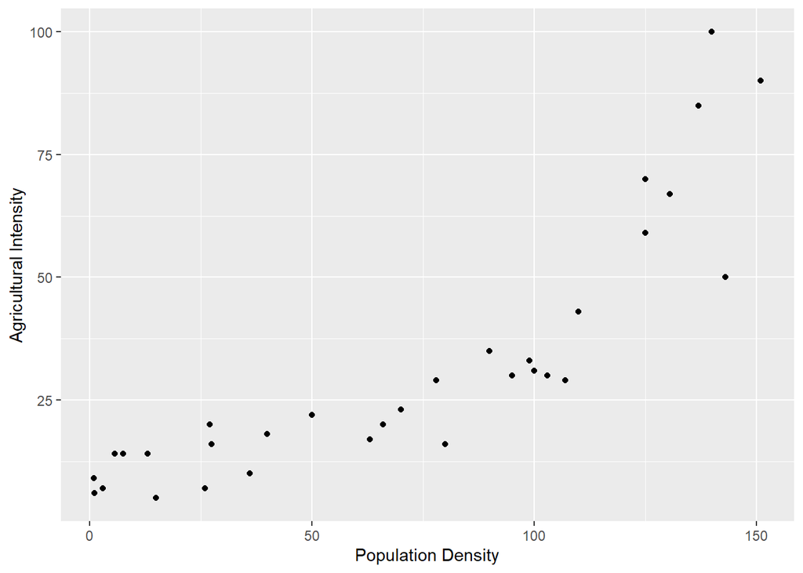

```r
gf_point(AgIntensity ~ PopDensity, data = ag,
              ylab="Agricultural Intensity",
              xlab="Population Density")
```

### 2.4.

What is the simplest form (linear, nonlinear, etc) of the relationship between agricultural intensity and population density?

### 2.5.

Is it appropriate to interpret the calculated correlation coefficient or create a linear model for these data?

> No, it is not appropriate to interpret the calculated correlation coefficient or create a linear model for these data. Correlation and linear models are specifically designed to measure and describe linear relationships. Since this relationship is nonlinear, a straight line does not accurately represent the trend, and the correlation coefficient may be misleading.